# LEGO as an investment: out-of-sample tests of the hedonic premium

Hiro, Hendrik, Stefan

23 October 2026

# 1. Introduction: research questions and hypotheses

Dobrynskaya and Kishilova (2022, *LEGO: The Toy of Smart Investors*, RIBF) report that retired LEGO sets earned about 11% a year on the secondary market between 1987 and 2015, and that a hedonic regression on theme, size and release year explains about half of the variation across sets (R² = 0.47). A **hedonic model** explains a set’s premium over its retail price by the set’s characteristics: theme, size, age, pieces, minifigures and retail price. The regression is fitted and scored on the same sets, so it says which sets *did* appreciate, not which sets *will*. With the authors’ own published data (Mendeley Data v9hhs66vm3) we ask three questions:

|  | Research question | Null hypothesis (H<sub>0</sub>) and alternative | Sections |
| --- | --- | --- | --- |
| **RQ1 Generalise** | Does the hedonic relation predict the return of sets, themes and release years the model has never seen? | **H1<sub>0</sub>.** Out-of-sample R² ≤ 0: the model predicts no better than the naive mean. *Alternative: R² > 0.* | 3.1 |
| **RQ2 Model class** | Do other regressions, including non-linear models, capture the hedonic characteristics of LEGO? | **H2<sub>0</sub>.** Penalised (ridge, LASSO, elastic net) and non-linear models (tree, random forest, XGBoost) do not beat OLS out of sample on the same features. *Alternative: they beat OLS.* | 3.2 |
| **RQ3 Persist** | Did the premium continue after 2015, and does 2015 information predict the forward return? | **H3<sub>0</sub>.** The December 2015 premium over retail has no effect on the forward return (coefficient = 0). *Alternative: a negative effect (mean reversion).* | 3.3 to 3.6 |

RQ1 and RQ2 work on the 2015 cross-section. RQ3 works through time, on 2018-2019 prices the original study did not model. Each H<sub>0</sub> is the no-effect case: rejecting it supports the alternative. H1<sub>0</sub> and H2<sub>0</sub> are judged on out-of-sample R², without a formal significance test; H3<sub>0</sub> is a t-test with robust (HC1) standard errors.

# 2. Data and methodology

## 2.1 Data and sample

```r
library(tidyverse)      # data handling and plots
library(lubridate)      # year() and month()
library(readxl)         # read the Excel files
library(glmnet)         # ridge, LASSO and elastic net
library(rpart)          # regression tree
library(randomForest)   # random forest
library(sandwich)       # robust and clustered standard errors
library(knitr)          # kable() tables
has_xgb <- requireNamespace("xgboost", quietly = TRUE)   # TRUE if xgboost is installed
if (has_xgb) library(xgboost)                            # load it only if it is there

data_dir <- "."   # the two data files are in the same folder as this file

# read the 2015 file: one row per set
raw_2015 <- read_excel(file.path(data_dir, "DiB whole sample Dec 2015 prices.xlsx"),
                       sheet = "DATA", na = c("", "NA", "ND"))   # "ND" means no data
# short column names
names(raw_2015) <- c("id", "theme", "name", "year", "pieces", "minifigs",
                     "p_new_2015", "p_used_2015", "p_retail", "age", "size")

# count the sets that fail each filter below (shown in Section 2.2)
drop_counts <- raw_2015 %>%
  mutate(across(c(minifigs, p_new_2015, p_used_2015), ~ suppressWarnings(as.numeric(.x)))) %>%   # text to numbers
  summarise(`In the 2015 file` = n(),                                                 # all rows
            `No retail price` = sum(is.na(p_retail) | p_retail <= 0),                 # retail price missing or 0
            `New price 0 ("no sale") or missing` = sum(is.na(p_new_2015) | p_new_2015 <= 0),
            `Minifigures missing` = sum(is.na(minifigs)),
            `Released in 2015` = sum(year >= 2015, na.rm = TRUE))                     # would give a zero holding period

# build the 2015 sample
sets <- raw_2015 %>%
  mutate(across(c(minifigs, p_new_2015, p_used_2015), as.numeric),   # text to numbers
         id = as.character(id),                                      # id as text, to join with the 2018 file
         theme = relevel(factor(theme), ref = "Miscellaneous"),       # same reference theme as the original study
         size = factor(size, levels = 1:4),                          # size group: 1 = biggest, 4 = smallest
         year_f = factor(year),                                      # release year as dummies
         log_retail = log(p_retail)) %>%                             # log retail price
  filter(p_new_2015 > 0, p_retail > 0, !is.na(minifigs),             # a price of 0 means "no sale"
         year < 2015) %>%                                            # y15 below divides by 2015 - year
  droplevels() %>%                                                   # remove empty factor levels
  mutate(y15 = log(p_new_2015 / p_retail) / (2015 - year),           # annual return since release (log, p.a.)
         prem15 = log(p_new_2015 / p_retail),                        # cumulative return over retail (the premium, log)
         log_p15 = log(p_new_2015))                                  # log price in Dec 2015

# read the monthly prices, January 2018 to April 2019
raw_1819 <- read_excel(file.path(data_dir, "DiB whole sample Jan 2018 - Apr 2019 prices.xlsx"),
                       skip = 1, na = c("", "NA", "ND"))             # row 1 is a title
month_cols <- names(raw_1819)[-(1:6)]                                # month headers are Excel date numbers
names(raw_1819)[-(1:6)] <- as.character(as.Date(as.numeric(month_cols), origin = "1899-12-30"))   # turn them into dates
prices_1819 <- raw_1819 %>%
  mutate(id = as.character(id)) %>%                                  # id as text
  select(id, matches("^20")) %>%                                     # keep id and the 16 month columns
  pivot_longer(-id, names_to = "date", values_to = "p") %>%          # one row per set and month
  mutate(date = as.Date(date), p = as.numeric(p)) %>%                # date and price as proper types
  filter(!is.na(p), p > 0)                                           # keep months with a price

# last observed price of each set (April 2019 for almost all sets)
p_end <- prices_1819 %>%
  group_by(id) %>%
  slice_max(date, n = 1, with_ties = FALSE) %>%                      # latest month per set
  ungroup() %>%
  transmute(id, date_end = date, p_end = p)
# price in January 2018
p_jan18 <- prices_1819 %>% filter(date == as.Date("2018-01-01")) %>% transmute(id, p_jan18 = p)

# forward returns after 2015
sets <- sets %>%
  left_join(p_end, by = "id") %>%                                    # add the last price
  left_join(p_jan18, by = "id") %>%                                  # add the January 2018 price
  mutate(h  = as.numeric(date_end - as.Date("2015-12-01")) / 365.25,   # years from Dec 2015 to the last price
         h2 = as.numeric(date_end - as.Date("2018-01-01")) / 365.25,   # years from Jan 2018 to the last price
         y_fwd  = log(p_end / p_new_2015) / h,                         # forward return 2015-19 (log, p.a.)
         y_fwd2 = ifelse(h2 > 0.5, log(p_end / p_jan18) / h2, NA))     # forward return 2018-19, clean window (log, p.a.)

# helper: price of each set in one month, as a column with the given name
p_at <- function(d, name) prices_1819 %>% filter(date == as.Date(d)) %>% transmute(id, !!name := p)
sets <- sets %>% left_join(p_at("2019-04-01", "p_apr19"), by = "id")   # add the April 2019 price

# for the machine-learning models: pool rare themes and early years.
# the rule uses only the number of sets per level, not the returns
sets <- sets %>%
  mutate(theme_ml = fct_lump_min(theme, min = 15, other_level = "Other"),           # themes with < 15 sets become "Other"
         year_ml  = factor(ifelse(year < 1995, "pre-1995", as.character(year))),   # years before 1995 in one group
         pieces_sq = pieces^2,                                                       # pieces squared
         age = as.numeric(age))                                                      # age in years, from the data file

# small helpers for numbers in the text
f3  <- function(x) formatC(x, format = "f", digits = 3)                       # 3 decimals
f2  <- function(x) formatC(x, format = "f", digits = 2)                       # 2 decimals
pct <- function(x) paste0(formatC(100 * x, format = "f", digits = 1), "%")    # percent with 1 decimal
num <- function(x) format(x, big.mark = ",")                                  # thousands separator
```

```r
# simple return of each set from Dec 2015 to Apr 2019
head_fwd <- sets %>% filter(!is.na(p_apr19)) %>% transmute(R = p_apr19 / p_new_2015 - 1)
head_median <- median(head_fwd$R)   # the typical set
head_mean   <- mean(head_fwd$R)     # equal-weighted portfolio of all sets
head_up     <- mean(head_fwd$R > 0) # share of sets that gained
```

The sample: 2,300 retired sets with a retail price and a December 2015 secondary-market price

| Measure | Sets | Mean | Median | SD | Share > 0 |
| --- | --- | --- | --- | --- | --- |
| Annual return since release, to Dec 2015 (log, p.a.) | 2300 | 0.148 | 0.114 | 0.186 | 0.904 |
| Cumulative return over retail, Dec 2015 (premium, log) | 2300 | 0.747 | 0.675 | 0.632 | 0.904 |
| Forward return 2015-19, Dec 2015 to Apr 2019 (log, p.a.) | 2271 | -0.029 | -0.017 | 0.153 | 0.439 |
| Forward return 2018-19, Jan 2018 to Apr 2019 (log, p.a.) | 2205 | -0.036 | -0.023 | 0.195 | 0.425 |

**Result.** The sample holds 2,300 retired sets released between 1981 and 2014. Up to December 2015 the median set earned 11.4% a year (mean 14.8%, log terms), close to the 11% reported by Dobrynskaya and Kishilova, and 90.4% of sets traded above their retail price. After 2015 the picture changes. From December 2015 to April 2019 (40 months) the median set’s price changed by -5.5% and an equal-weighted portfolio of all sets by 2.7%, in simple returns before costs; 56.1% of sets fell in price. The models use annualised log returns, whose mean (-2.9% a year) lies below the log of the average return.

## 2.2 Data source, comparability and dropped sets

**Source.** The sheet “About the sample” in the 2015 file describes BrickPicker’s price guide: eBay sold auctions, bought via Terapeak, “aggregate[d] into our monthly Price Guide”; values “are approximate ones and are several months old”. The prices are therefore monthly aggregates of realised eBay sales, not single trades or asking prices. The 2018-2019 file does not name its source.

**Are the two files comparable?** If the 2018-2019 file used another source or another condition (for example used instead of new sets), every forward return would shift by the same amount and look like a crash. We check this directly.

```r
# sets that are in both files, with theme and year as written in the 2018 file
cmp <- sets %>%
  filter(!is.na(p_jan18)) %>%                                        # sets with a January 2018 price
  inner_join(raw_1819 %>% transmute(id = as.character(id), theme_1819 = theme, year_1819 = `year of release`),
             by = "id")
# checks: same sets, and new or used condition
cmp_stats <- tibble(
  Check = c("Sets in both files", "Same theme in both files", "Same release year in both files",
            "Median log change, Dec 2015 new price to Jan 2018", "Median log change, Dec 2015 used price to Jan 2018",
            "Correlation of log prices, Dec 2015 new vs Jan 2018"),
  Value = c(nrow(cmp),
            mean(cmp$theme_1819 == as.character(cmp$theme)),                 # share with the same theme
            mean(cmp$year_1819 == cmp$year),                                 # share with the same year
            median(log(cmp$p_jan18 / cmp$p_new_2015)),                       # near 0 if 2018 holds new prices
            median(log(cmp$p_jan18 / cmp$p_used_2015), na.rm = TRUE),        # near 0 if 2018 holds used prices
            cor(log(cmp$p_jan18), log(cmp$p_new_2015))))
```

Do the 2015 and 2018-2019 files describe the same sets in the same condition?

| Check | Value |
| --- | --- |
| Sets in both files | 2205.000 |
| Same theme in both files | 1.000 |
| Same release year in both files | 1.000 |
| Median log change, Dec 2015 new price to Jan 2018 | -0.015 |
| Median log change, Dec 2015 used price to Jan 2018 | 0.537 |
| Correlation of log prices, Dec 2015 new vs Jan 2018 | 0.908 |

Why sets leave the sample (a set can fail several checks)

| Reason | Sets |
| --- | --- |
| In the 2015 file | 2322 |
| No retail price | 17 |
| New price 0 (“no sale”) or missing | 4 |
| Minifigures missing | 3 |
| Released in 2015 | 0 |
| Kept in the 2015 sample | 2300 |
| Of these, no Jan 2018 price | 95 |
| Of these, no 2018-2019 price at all | 29 |

**Result.** The files describe the same 2,205 sets: theme and release year agree for 100.0% and 100.0% of them. Prices line up with the 2015 *new* price (median log change -0.015) and not with the *used* price (0.537), and log prices correlate 0.91, so the 2018 file holds new-condition prices of the same sets. The check cannot detect a change of method worth a few percent (see Section 4). Few sets are dropped, but those without prices are probably the least traded, so the sample tilts slightly towards liquid sets.

## 2.3 Return measures

| Measure | Code | Definition (log) | Window | Used for |
| --- | --- | --- | --- | --- |
| Annual return since release | `y15` | ln(P Dec 2015 / P retail) / (2015 - release year) | Release to Dec 2015, per year | H1, H2 target; H3 feature |
| Cumulative return over retail (premium) | `prem15` | ln(P Dec 2015 / P retail) | Release to Dec 2015, total | Hedonic baseline target; H3 feature |
| Forward return 2015-19 | `y_fwd` | ln(P Apr 2019 / P Dec 2015) / 3.33 years | Dec 2015 to Apr 2019, per year | H2, H3 target |
| Forward return 2018-19 | `y_fwd2` | ln(P Apr 2019 / P Jan 2018) / 1.25 years | Jan 2018 to Apr 2019, per year | H2, H3 target, clean window |

The return earned before 2015 is kept apart from the return earned after it, so no test scores a model on the price it was trained on. In the clean window the December 2015 price enters only the features, not the target.

## 2.4 Test design

| Test | Fit, then score | Features | Target | Shortcut it removes |
| --- | --- | --- | --- | --- |
| 0 Baseline | All sets, in sample | Theme, size, release-year dummies | Cumulative return over retail | Coding errors (Section 2.5) |
| 1 Unseen sets (H1, H2) | 5-fold CV: random sets; whole themes; whole years | + pieces, minifigures, retail price | Annual return since release | Scoring on the fitted sets |
| 2 Forward return (H2, H3) | 5-fold CV by set | Characteristics, then + Dec 2015 price history | Forward return 2015-19 | Hindsight about returns after 2015 |
| 3 Clean window (H2, H3) | 5-fold CV by set | Same, as of Dec 2015 | Forward return 2018-19 | Dec 2015 price in both feature and target: a quote error fakes a reversal |

The *2015 price history* is the December 2015 price, the cumulative return over retail and the annual return since release. Eight models compete on the same folds: the naive mean and OLS (linear), ridge, LASSO and elastic net (penalised, penalty chosen by cross-validation inside each training fold), and a regression tree, a random forest and XGBoost (non-linear, fixed settings). Scores: out-of-sample R² (above 0 beats the mean), RMSE, rank correlation, median hit and sign hit ratios.

```r
# feature sets. Dummies are built once on all sets, so every fold has the same columns
f_base  <- ~ theme_ml + size + year_ml                                       # baseline hedonic variables
f_full  <- ~ theme_ml + size + year_ml + pieces + pieces_sq + minifigs + log_retail   # plus set characteristics
f_mom   <- ~ theme_ml + size + year_ml + pieces + pieces_sq + minifigs + log_retail + prem15 + log_p15 + y15   # plus 2015 price history
rhs_full <- c("theme_ml", "size", "year_ml", "pieces", "minifigs", "log_retail")   # same features for the tree models
rhs_mom  <- c(rhs_full, "prem15", "log_p15", "y15")

# fit one model on the training rows and predict the test rows
fit_predict <- function(model, X_tr, y_tr, X_te, df_tr, df_te, rhs, seed = 42){
  set.seed(seed)                                                       # same seed for every model
  switch(model,
    "Naive (mean)"  = rep(mean(y_tr), nrow(X_te)),                     # predict the training mean for every set
    "OLS"           = { b <- coef(lm.fit(cbind(1, X_tr), y_tr))        # least squares with an intercept
                        b[is.na(b)] <- 0                               # collinear columns get weight 0
                        as.numeric(cbind(1, X_te) %*% b) },            # predictions for the test rows
    "Ridge"         = as.numeric(predict(cv.glmnet(X_tr, y_tr, alpha = 0),   X_te, s = "lambda.min")),   # penalty chosen by CV
    "LASSO"         = as.numeric(predict(cv.glmnet(X_tr, y_tr, alpha = 1),   X_te, s = "lambda.min")),
    "Elastic net"   = as.numeric(predict(cv.glmnet(X_tr, y_tr, alpha = 0.5), X_te, s = "lambda.min")),
    "Tree"          = predict(rpart(reformulate(rhs, "y"), data = df_tr,
                                    minbucket = 30, cp = 0.001, maxdepth = 4, xval = 0), df_te),
    "Random forest" = predict(randomForest(reformulate(rhs, "y"), data = df_tr,
                                           ntree = 300, mtry = max(2, floor(length(rhs) / 3)),   # 300 trees, 1/3 of features per split
                                           nodesize = 10, sampsize = floor(0.7 * nrow(df_tr)), replace = FALSE), df_te),
    "XGBoost"       = { if (!has_xgb) return(rep(NA_real_, nrow(X_te)))   # skip if xgboost is not installed
                        fit <- xgb.train(params = list(objective = "reg:squarederror", eta = 0.05, max_depth = 3,
                                                       subsample = 0.8, colsample_bytree = 0.8, lambda = 1, nthread = 2),
                                         data = xgb.DMatrix(X_tr, label = y_tr), nrounds = 300, verbose = 0)
                        predict(fit, X_te) })
}

# out-of-fold predictions for one target and one feature set.
# group = NULL gives random folds by set; group = "theme" or "year" keeps each group in one fold
cv_models <- function(df, target, formula_x, rhs, k = 5, seed = 42, group = NULL,
                      models = c("Naive (mean)", "OLS", "Ridge", "LASSO", "Elastic net", "Tree", "Random forest", "XGBoost")){
  df <- df %>%
    filter(!is.na(.data[[target]]), if_all(all.vars(formula_x), ~ !is.na(.x))) %>%   # rows with no missing values
    mutate(y = .data[[target]])                                                      # target column called y
  X <- model.matrix(formula_x, data = df)[, -1, drop = FALSE]        # dummy matrix without the intercept
  set.seed(seed)
  if (is.null(group)) {
    fold <- sample(rep(1:k, length.out = nrow(df)))                  # each set gets a random fold
  } else {
    g <- unique(df[[group]])                                         # list of groups
    fold <- sample(rep(1:k, length.out = length(g)))[match(df[[group]], g)]   # each group gets a random fold
  }
  lapply(models, function(m){
    pred <- rep(NA_real_, nrow(df))                                  # empty vector for the predictions
    for (f in 1:k) {
      tr <- fold != f                                                # training rows: all other folds
      pred[!tr] <- fit_predict(m, X[tr, , drop = FALSE], df$y[tr],   # fit on them and predict fold f
                               X[!tr, , drop = FALSE], df[tr, ], df[!tr, ], rhs, seed = seed + f)
    }
    tibble(Model = m, id = df$id, y = df$y, pred = pred)             # one row per set
  }) %>%
    bind_rows() %>%                                                  # all models in one table
    filter(!is.na(pred))                                             # drops XGBoost if it is not installed
}

# scores of the out-of-fold predictions, one row per model
score <- function(oof){
  oof %>% group_by(Model) %>%
    summarise(`OOS R2`     = 1 - mean((y - pred)^2) / mean((y - mean(y))^2),   # out-of-sample R squared
              RMSE         = sqrt(mean((y - pred)^2)),
              `Rank corr.` = if (sd(pred) == 0) NA else cor(pred, y, method = "spearman"),
              `Median hit` = if (sd(pred) == 0) NA else mean((pred > median(pred)) == (y > median(y))),   # same side of the median
              `Sign hit`   = mean(pred * y > 0),                                # same sign as the true value
              `Share y > 0` = mean(y > 0),                                      # compare the sign hit with this
              .groups = "drop") %>%
    arrange(RMSE)                                                               # best model first
}
```

## 2.5 Baseline: the hedonic regression reproduces the published estimates

```r
# the published hedonic regression: cumulative return over retail on theme, size and year dummies
fit_base <- lm(log(p_new_2015 / p_retail) ~ theme + size + year_f, data = sets)
```

Baseline hedonic regression: our estimates vs the published ones

| Coefficient | Our estimate | Published | Difference |
| --- | --- | --- | --- |
| Batman theme | 0.4501 | 0.4484 | 0.0017 |
| Discovery theme | 0.6145 | 0.6124 | 0.0021 |
| Size group 2 (vs 1) | -0.2268 | -0.2438 | 0.0170 |
| R squared | 0.4701 | 0.4695 | 0.0006 |

**Result.** Our estimates match the published ones: the largest difference is 0.017 and the R² is 0.470 against 0.470. Small differences can come from the sets with missing values that we drop. All later differences therefore come from the test design, not from the data. Note what the R² means: the regression has 77 parameters for 2,300 sets, all fitted and evaluated on the same data.

```r
# hedonic regression with age as one number; target: cumulative return over retail
fit_hed <- list(`Theme, size, age` = lm(prem15 ~ theme_ml + size + age, data = sets))
```

```r
# one OLS fit to one row per coefficient: estimate, standard error, t, p and stars
coef_table <- function(fit, se = c("classical", "HC1")){
  se <- match.arg(se)                                                # "classical" or "HC1"
  b  <- coef(fit)                                                    # all coefficients
  aliased <- names(b)[is.na(b)]                                      # collinear columns (lm gives NA)
  b  <- b[!is.na(b)]                                                 # keep the estimated ones
  V  <- if (se == "classical") vcov(fit) else vcovHC(fit, type = "HC1")   # covariance matrix
  s  <- sqrt(diag(V))[names(b)]                                      # standard errors
  t  <- b / s                                                        # t-statistics
  p  <- 2 * pt(-abs(t), df = df.residual(fit))                       # two-sided p-values
  bind_rows(tibble(Term = names(b), Estimate = b, SE = s, t = t, p = p),
            tibble(Term = aliased, Estimate = NA_real_, SE = NA_real_, t = NA_real_, p = NA_real_)) %>%
    mutate(Sig. = case_when(is.na(p) ~ "aliased", p < 0.01 ~ "***", p < 0.05 ~ "**", p < 0.1 ~ "*", TRUE ~ ""))
}

# several fits to one table: each cell is "estimate stars (SE)", fit statistics at the bottom
reg_table <- function(fits, digits = 3){
  fmt <- function(x) formatC(x, format = "g", digits = digits)       # "g" keeps very small numbers readable
  cells <- imap(fits, function(fit, nm){
    coef_table(fit) %>%
      transmute(Term, !!nm := ifelse(is.na(Estimate), "aliased",
                                     paste0(fmt(Estimate), Sig., " (", fmt(SE), ")")))
  }) %>% reduce(full_join, by = "Term")                              # one column per model
  terms <- unique(unlist(map(fits, ~ names(coef(.x)))))              # coefficient order as in the models
  cells <- cells %>% slice(match(terms, Term)) %>% mutate(across(-Term, ~ replace_na(.x, "")))
  stats <- map_dfc(fits, function(fit){
    s <- summary(fit)
    c(nobs(fit),                                                     # number of sets
      formatC(s$r.squared, format = "f", digits = 3),
      formatC(s$adj.r.squared, format = "f", digits = 3),
      formatC(pf(s$fstatistic[1], s$fstatistic[2], s$fstatistic[3], lower.tail = FALSE), format = "e", digits = 2))   # F-test p
  })
  bind_rows(cells, bind_cols(Term = c("Sets (N)", "R squared", "Adjusted R squared", "F-test p-value"), stats))
}

# non-dummy variables only: classical and robust (HC1) tests side by side
robust_check <- function(fits, keep){
  imap_dfr(fits, function(fit, nm){
    full_join(coef_table(fit, "classical") %>% select(Term, Estimate, t, p, Sig.),
              coef_table(fit, "HC1") %>% select(Term, `t (HC1)` = t, `p (HC1)` = p, `Sig. (HC1)` = Sig.),
              by = "Term") %>%
      filter(Term %in% keep) %>%                                     # keep the listed variables
      mutate(Model = nm, .before = 1,
             Estimate = formatC(Estimate, format = "g", digits = 3))   # as text, so kable does not round small values to 0
  })
}
cont_vars <- c("(Intercept)", "age", "pieces", "pieces_sq", "minifigs", "log_retail", "prem15", "log_p15", "y15")
```

OLS on all sets. Target: cumulative return over retail, Dec 2015. Estimate (classical SE); *** p < 0.01, ** p < 0.05, * p < 0.1. Reference levels: theme Miscellaneous, size group 1

| Term | Theme, size, age |
| --- | --- |
| (Intercept) | 0.175 (0.11) |
| theme_mlAdvanced models | 0.477*** (0.134) |
| theme_mlAgents | 0.101 (0.146) |
| theme_mlArchitecture | -0.0272 (0.135) |
| theme_mlAtlantis | -0.261* (0.142) |
| theme_mlBatman | 0.55*** (0.126) |
| theme_mlBionicle | 0.0703 (0.0996) |
| theme_mlCars | 0.00401 (0.14) |
| theme_mlCastle | -0.0633 (0.104) |
| theme_mlCity | 0.101 (0.0984) |
| theme_mlCreator | 0.102 (0.103) |
| theme_mlFriends | 0.128 (0.107) |
| theme_mlHarry Potter | 0.459*** (0.117) |
| theme_mlHero factory | 0.227** (0.107) |
| theme_mlIndiana Jones | 0.592*** (0.155) |
| theme_mlLegends of China | -0.0882 (0.109) |
| theme_mlLord of the Rings | -0.108 (0.127) |
| theme_mlNinjago | 0.0733 (0.106) |
| theme_mlPirates | -0.117 (0.119) |
| theme_mlPower miners | 0.35** (0.154) |
| theme_mlSeasonal | 0.399*** (0.112) |
| theme_mlSpace | -0.205* (0.112) |
| theme_mlStar Wars | 0.0971 (0.0976) |
| theme_mlSuper Heroes | 0.446*** (0.119) |
| theme_mlTechnic | -0.0477 (0.104) |
| theme_mlTeenage mutant ninja turtle | -0.184 (0.154) |
| theme_mlThe Lego movie | -0.0384 (0.149) |
| theme_mlTrains | 0.257* (0.135) |
| theme_mlOther | 0.116 (0.103) |
| size2 | -0.163** (0.065) |
| size3 | -0.148** (0.0627) |
| size4 | 0.099* (0.0594) |
| age | 0.0662*** (0.00255) |
| Sets (N) | 2300 |
| R squared | 0.406 |
| Adjusted R squared | 0.398 |
| F-test p-value | 1.27e-229 |

## 2.6 Why we do not simply train on 2015 and test on 2019

A natural first test is to train on the 2015 cross-section and “predict” the 2018-2019 prices of the same sets with the same target definition, the return since release. It gives hit ratios near 70%. This is not forecasting.

```r
# return since release measured at the last 2018-2019 price
tp <- sets %>% filter(!is.na(y_fwd)) %>%
  mutate(y_1819 = log(p_end / p_retail) /
           (year(date_end) - year + (month(date_end) - 12) / 12))   # divided by the age at that date
```

Persistence, not prediction

| Check | Value |
| --- | --- |
| Correlation: return since release in 2015 vs in 2019 | 0.537 |
| Median hit of the rule “rank 2019 like 2015” (no model) | 0.721 |
| Median hit of the same rule against the forward return | 0.408 |

**Result.** The return since release measured in 2019 contains the return since release measured in 2015 plus three more years, so the two are correlated 0.537. Ranking sets by their own 2015 return, with no model, already gives a hit ratio of 72.1%. Against the forward return the same rule scores 40.8%, below a coin flip. The rule used in every test below: the test target must never share information with the training target, and the benchmark is the simplest rule that uses the same information.

# 3. Results and analysis

All cross-validation runs are computed first, so that H2 can compare models across every test.

```r
# Test 1, random folds. Baseline variables: only the naive model and OLS
oof_base <- cv_models(sets, "y15", f_base, c("theme_ml", "size", "year_ml"), models = c("Naive (mean)", "OLS"))
# baseline variables plus characteristics: all eight models
oof_full <- cv_models(sets, "y15", f_full, rhs_full)

res2 <- bind_rows(score(oof_base) %>% mutate(Features = "Baseline (theme, size, year)"),
                  score(oof_full) %>% mutate(Features = "Baseline + pieces, minifigures, retail price")) %>%
  select(Features, everything())
```

```r
# Test 1, grouped folds. Unseen themes: no theme dummies
f_no_theme   <- ~ size + year_ml + pieces + pieces_sq + minifigs + log_retail
rhs_no_theme <- c("size", "year_ml", "pieces", "minifigs", "log_retail")
# unseen years: age as a number instead of year dummies
f_no_year    <- ~ theme_ml + size + age + pieces + pieces_sq + minifigs + log_retail
rhs_no_year  <- c("theme_ml", "size", "age", "pieces", "minifigs", "log_retail")
grp_models   <- c("Naive (mean)", "OLS", "Random forest")   # linear benchmark and the best non-linear model

# four runs: random and grouped folds for each question, same features within each question
grp_runs <- list(
  list(Question = "Unseen themes", Folds = "Random sets",  f = f_no_theme, rhs = rhs_no_theme, group = NULL),
  list(Question = "Unseen themes", Folds = "Whole themes", f = f_no_theme, rhs = rhs_no_theme, group = "theme"),
  list(Question = "Unseen years",  Folds = "Random sets",  f = f_no_year,  rhs = rhs_no_year,  group = NULL),
  list(Question = "Unseen years",  Folds = "Whole years",  f = f_no_year,  rhs = rhs_no_year,  group = "year"))

res2_grp <- map_dfr(grp_runs, function(r)
  score(cv_models(sets, "y15", r$f, r$rhs, group = r$group, models = grp_models)) %>%
    mutate(Question = r$Question, Folds = r$Folds)) %>%
  select(Question, Folds, Model, `OOS R2`, RMSE, `Rank corr.`)
```

```r
# Test 2: forward return 2015-19
oof_f_char <- cv_models(sets, "y_fwd", f_full, rhs_full)                  # characteristics only
oof_f_mom  <- cv_models(sets, "y_fwd", f_mom,  rhs_mom)                   # plus the 2015 price history
oof_f_y15  <- cv_models(sets, "y_fwd", ~ y15, "y15", models = c("OLS"))   # the annual return since release alone

res3 <- bind_rows(score(oof_f_char) %>% mutate(Features = "Characteristics"),
                  score(oof_f_mom)  %>% mutate(Features = "Characteristics + 2015 price history"),
                  score(oof_f_y15)  %>% mutate(Features = "Annual return since release only")) %>%
  select(Features, everything())
```

```r
# Test 3: clean window, forward return 2018-19 with features as of Dec 2015
oof_c_char <- cv_models(sets, "y_fwd2", f_full, rhs_full)
oof_c_mom  <- cv_models(sets, "y_fwd2", f_mom,  rhs_mom)

res4 <- bind_rows(score(oof_c_char) %>% mutate(Features = "Characteristics"),
                  score(oof_c_mom)  %>% mutate(Features = "Characteristics + 2015 price history")) %>%
  select(Features, everything())
best4 <- res4 %>% filter(Model != "Naive (mean)") %>% slice_min(RMSE, n = 1)   # lowest error in this window
```

## 3.1 H1: the hedonic relation generalises, least to new release years

Held-out sets (5-fold CV by set), OLS against the naive mean. Target: annual return since release

| Features | Model | OOS R2 | RMSE | Rank corr. | Median hit | Sign hit | Share y > 0 |
| --- | --- | --- | --- | --- | --- | --- | --- |
| Baseline (theme, size, year) | OLS | 0.226 | 0.164 | 0.456 | 0.678 | 0.880 | 0.904 |
| Baseline (theme, size, year) | Naive (mean) | -0.001 | 0.186 | -0.006 | 0.504 | 0.904 | 0.904 |
| Baseline + pieces, minifigures, retail price | OLS | 0.293 | 0.156 | 0.529 | 0.688 | 0.862 | 0.904 |
| Baseline + pieces, minifigures, retail price | Naive (mean) | -0.001 | 0.186 | -0.006 | 0.504 | 0.904 | 0.904 |

OLS on grouped folds vs random folds, same features within each question. Target: annual return since release

| Question | Folds | Model | OOS R2 | RMSE | Rank corr. |
| --- | --- | --- | --- | --- | --- |
| Unseen themes | Random sets | OLS | 0.251 | 0.161 | 0.472 |
| Unseen themes | Random sets | Naive (mean) | -0.001 | 0.186 | -0.006 |
| Unseen themes | Whole themes | OLS | 0.231 | 0.163 | 0.455 |
| Unseen themes | Whole themes | Naive (mean) | -0.009 | 0.187 | -0.145 |
| Unseen years | Random sets | OLS | 0.234 | 0.163 | 0.524 |
| Unseen years | Random sets | Naive (mean) | -0.001 | 0.186 | -0.006 |
| Unseen years | Whole years | OLS | 0.135 | 0.173 | 0.456 |
| Unseen years | Whole years | Naive (mean) | -0.021 | 0.188 | -0.122 |

**Result.** H1<sub>0</sub> is rejected. The naive mean scores about zero by construction. On held-out sets, OLS with theme, size and release year keeps an out-of-sample R² of 0.226; adding pieces, minifigures and the retail price lifts it to 0.293. Holding out whole themes, OLS reaches 0.231 against 0.251 with random folds on the same features. Holding out whole release years, it reaches 0.135 against 0.234: still above the naive mean, but much weaker. Two possible reasons, which we do not test: each release cohort meets its own market, and the release year also fixes the holding period of the target, so an unseen year forces the model to extrapolate. The target is the annualised return, so R² is lower than the 0.47 of the cumulative return in Section 2.5.

## 3.2 H2: non-linear models capture more, mainly in the cross-section

All models on held-out sets (5-fold CV by set), full hedonic features. Target: annual return since release

| Features | Model | OOS R2 | RMSE | Rank corr. | Median hit | Sign hit | Share y > 0 |
| --- | --- | --- | --- | --- | --- | --- | --- |
| Baseline + pieces, minifigures, retail price | XGBoost | 0.486 | 0.133 | 0.596 | 0.710 | 0.911 | 0.904 |
| Baseline + pieces, minifigures, retail price | Random forest | 0.486 | 0.133 | 0.640 | 0.735 | 0.914 | 0.904 |
| Baseline + pieces, minifigures, retail price | Tree | 0.364 | 0.148 | 0.484 | 0.646 | 0.913 | 0.904 |
| Baseline + pieces, minifigures, retail price | LASSO | 0.297 | 0.156 | 0.523 | 0.681 | 0.871 | 0.904 |
| Baseline + pieces, minifigures, retail price | Elastic net | 0.297 | 0.156 | 0.523 | 0.683 | 0.872 | 0.904 |
| Baseline + pieces, minifigures, retail price | Ridge | 0.296 | 0.156 | 0.528 | 0.689 | 0.869 | 0.904 |
| Baseline + pieces, minifigures, retail price | OLS | 0.293 | 0.156 | 0.529 | 0.688 | 0.862 | 0.904 |
| Baseline + pieces, minifigures, retail price | Naive (mean) | -0.001 | 0.186 | -0.006 | 0.504 | 0.904 | 0.904 |

Out-of-sample R², OLS vs random forest, every test

| Test | OLS | Random forest | Gain of random forest |
| --- | --- | --- | --- |
| Unseen sets | 0.293 | 0.486 | 0.193 |
| Unseen themes | 0.231 | 0.401 | 0.170 |
| Unseen release years | 0.135 | 0.164 | 0.029 |
| Forward return 2015-19, characteristics | 0.173 | 0.210 | 0.036 |
| Forward return 2015-19, + 2015 price history | 0.365 | 0.396 | 0.030 |
| Forward return 2018-19 (clean window), + 2015 price history | 0.092 | 0.097 | 0.004 |

**Result.** H2<sub>0</sub> is rejected for non-linear models but not for penalised ones. With the full hedonic features on unseen sets, the best penalised regression changes the out-of-sample R² of OLS by 0.005: shrinkage does not help at this sample size. The best tree model adds 0.193, so the hedonic relation has non-linearities or interactions that OLS misses; we do not test which. The random forest gains 0.193 over OLS on unseen sets and 0.170 on unseen themes, but only between 0.004 and 0.036 on unseen release years and on returns after 2015. Non-linear models capture the hedonic characteristics better in the cross-section; the advantage does not carry over through time.

## 3.3 H3: 2015 information predicts the 2015-19 return

Held-out sets (5-fold CV by set). Target: forward return 2015-19 (log, p.a.)

| Features | Model | OOS R2 | RMSE | Rank corr. | Median hit | Sign hit | Share y > 0 |
| --- | --- | --- | --- | --- | --- | --- | --- |
| Characteristics | Random forest | 0.210 | 0.136 | 0.507 | 0.692 | 0.690 | 0.439 |
| Characteristics | XGBoost | 0.202 | 0.136 | 0.496 | 0.684 | 0.666 | 0.439 |
| Characteristics | Ridge | 0.179 | 0.138 | 0.434 | 0.665 | 0.640 | 0.439 |
| Characteristics | LASSO | 0.178 | 0.139 | 0.432 | 0.662 | 0.642 | 0.439 |
| Characteristics | Elastic net | 0.178 | 0.139 | 0.432 | 0.664 | 0.641 | 0.439 |
| Characteristics | OLS | 0.173 | 0.139 | 0.431 | 0.663 | 0.642 | 0.439 |
| Characteristics | Tree | 0.137 | 0.142 | 0.390 | 0.627 | 0.621 | 0.439 |
| Characteristics | Naive (mean) | 0.000 | 0.153 | -0.015 | 0.486 | 0.559 | 0.439 |
| Characteristics + 2015 price history | Random forest | 0.396 | 0.119 | 0.659 | 0.744 | 0.738 | 0.439 |
| Characteristics + 2015 price history | XGBoost | 0.386 | 0.120 | 0.644 | 0.731 | 0.732 | 0.439 |
| Characteristics + 2015 price history | LASSO | 0.372 | 0.121 | 0.615 | 0.725 | 0.717 | 0.439 |
| Characteristics + 2015 price history | Elastic net | 0.372 | 0.121 | 0.614 | 0.727 | 0.715 | 0.439 |
| Characteristics + 2015 price history | Ridge | 0.371 | 0.121 | 0.614 | 0.723 | 0.717 | 0.439 |
| Characteristics + 2015 price history | OLS | 0.365 | 0.122 | 0.612 | 0.723 | 0.712 | 0.439 |
| Characteristics + 2015 price history | Tree | 0.270 | 0.130 | 0.542 | 0.694 | 0.690 | 0.439 |
| Characteristics + 2015 price history | Naive (mean) | 0.000 | 0.153 | -0.015 | 0.486 | 0.559 | 0.439 |
| Annual return since release only | OLS | 0.023 | 0.151 | 0.267 | 0.594 | 0.580 | 0.439 |

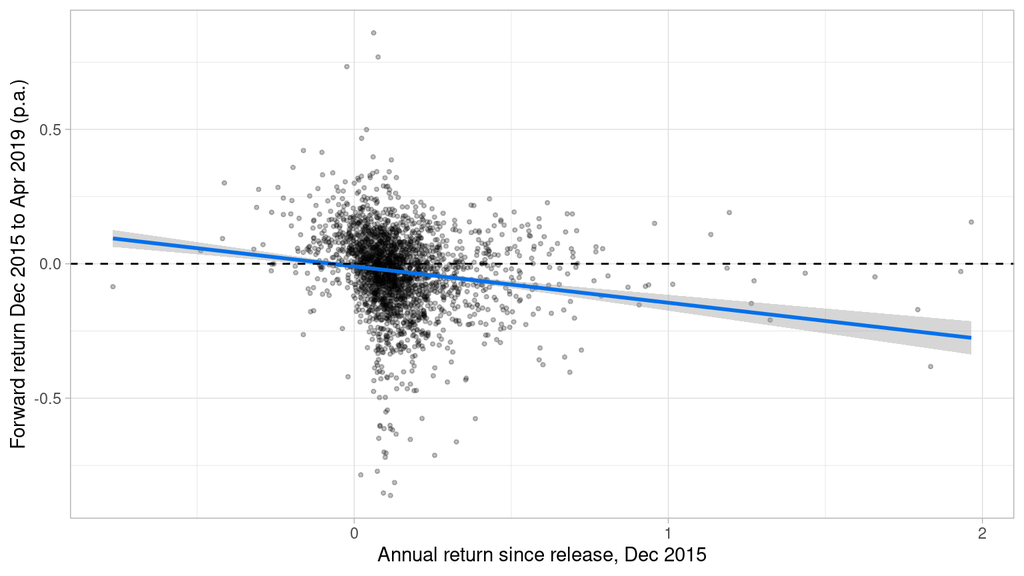

Past winners did worse afterwards: annual return since release against the forward return 2015-19

```r
sets %>% filter(!is.na(y_fwd)) %>%                                   # sets with a forward return
  ggplot(aes(x = y15, y = y_fwd)) +
  geom_point(alpha = 0.25, size = 0.8) +                             # one point per set
  geom_smooth(method = "lm", colour = "#0570EA") +                   # straight-line fit
  geom_hline(yintercept = 0, linetype = 2) +                         # zero return
  labs(x = "Annual return since release, Dec 2015", y = "Forward return Dec 2015 to Apr 2019 (p.a.)") +
  theme_light()
```

**Result.** Characteristics alone predict some of the forward return (out-of-sample R² up to 0.210). Adding the 2015 price history raises it to 0.396. The correlation between the annual return since release and the forward return is -0.162: the sets that had appreciated most did worse afterwards. Part of this is mechanical: a too-high December 2015 price quote raises the 2015 premium and lowers the measured forward return at the same time. Section 3.5 removes this link.

## 3.4 H3: the driver is the 2015 premium, not past return

OLS on all sets with a forward price. Age enters as one number in place of the release-year dummies. The target is the forward return 2015-19, held over the same window for every set.

```r
# feature sets with age as a number
f_char_agen <- ~ theme_ml + size + age + pieces + pieces_sq + minifigs + log_retail
f_mom_agen  <- ~ theme_ml + size + age + pieces + pieces_sq + minifigs + log_retail + prem15 + log_p15 + y15

# three OLS fits on all sets, target: forward return 2015-19
fits3 <- list(`Characteristics`                     = lm(update(f_char_agen, y_fwd ~ .), data = sets),
              `Characteristics + 2015 price history` = lm(update(f_mom_agen,  y_fwd ~ .), data = sets),
              `Annual return since release only`     = lm(y_fwd ~ y15, data = sets))

# key coefficients as on the slide: robust (HC1) t for non-dummy variables, classical t for themes
key_terms <- c(prem15 = "Cumulative return over retail, Dec 2015",
               y15 = "Annual return since release, Dec 2015",
               log_retail = "log retail price",
               age = "Age (years since release)",
               pieces = "Pieces (per 1,000)",
               minifigs = "Minifigures",
               theme_mlArchitecture = "Architecture",
               theme_mlCastle = "Castle",
               `theme_mlHarry Potter` = "Harry Potter",
               theme_mlBatman = "Batman",
               theme_mlAgents = "Agents")
key_table <- function(fit){
  cl <- coef_table(fit, "classical")
  hc <- coef_table(fit, "HC1")
  is_dummy <- grepl("^theme_ml|^size", cl$Term)                      # dummies: classical t
  tibble(Term = cl$Term, Estimate = cl$Estimate,
         t = ifelse(is_dummy, cl$t, hc$t[match(cl$Term, hc$Term)]))
}
key3 <- full_join(key_table(fits3[[1]]) %>% rename(`Char. only` = Estimate, `t, char. only` = t),
                  key_table(fits3[[2]]) %>% rename(`+ 2015 prices` = Estimate, `t, + 2015 prices` = t),
                  by = "Term") %>%
  filter(Term %in% names(key_terms)) %>%
  mutate(across(c(`Char. only`, `+ 2015 prices`), ~ ifelse(Term == "pieces", .x * 1000, .x)),   # pieces per 1,000
         Term = unname(key_terms[Term])) %>%
  slice(match(unname(key_terms), Term))
```

Key coefficients. Target: forward return 2015-19 (log, p.a.). t: robust (HC1) for non-dummy variables, classical for themes. Reference theme: Miscellaneous. Size dummies and pieces squared included.

| Term | Char. only | t, char. only | + 2015 prices | t, + 2015 prices |
| --- | --- | --- | --- | --- |
| Cumulative return over retail, Dec 2015 | NA | NA | -0.1523 | -13.84 |
| Annual return since release, Dec 2015 | NA | NA | -0.0288 | -1.11 |
| log retail price | -0.0324 | -4.86 | -0.0842 | -12.43 |
| Age (years since release) | -0.0110 | -12.70 | -0.0023 | -2.13 |
| Pieces (per 1,000) | 0.0662 | 1.63 | 0.1587 | 4.42 |
| Minifigures | -0.0019 | -1.11 | -0.0030 | -2.08 |
| Architecture | 0.1655 | 4.25 | 0.1822 | 5.42 |
| Castle | 0.1009 | 3.34 | 0.1013 | 3.88 |
| Harry Potter | 0.0670 | 1.99 | 0.1563 | 5.33 |
| Batman | -0.1642 | -4.54 | -0.0722 | -2.30 |
| Agents | -0.1390 | -3.32 | -0.1118 | -3.09 |

Full OLS output. Target: forward return 2015-19 (log, p.a.). Estimate (classical SE); *** p < 0.01, ** p < 0.05, * p < 0.1. Reference levels: theme Miscellaneous, size group 1

| Term | Characteristics | Characteristics + 2015 price history | Annual return since release only |
| --- | --- | --- | --- |
| (Intercept) | 0.125** (0.0488) | 0.293*** (0.0427) | -0.00965** (0.00405) |
| theme_mlAdvanced models | -0.00201 (0.0391) | 0.0647* (0.0339) |  |
| theme_mlAgents | -0.139*** (0.0419) | -0.112*** (0.0362) |  |
| theme_mlArchitecture | 0.166*** (0.0389) | 0.182*** (0.0336) |  |
| theme_mlAtlantis | 0.0392 (0.0404) | -0.00188 (0.035) |  |
| theme_mlBatman | -0.164*** (0.0361) | -0.0722** (0.0314) |  |
| theme_mlBionicle | 0.0664** (0.0284) | 0.0736*** (0.0246) |  |
| theme_mlCars | 0.028 (0.0399) | 0.0373 (0.0345) |  |
| theme_mlCastle | 0.101*** (0.0302) | 0.101*** (0.0261) |  |
| theme_mlCity | -0.0151 (0.0282) | 0.0129 (0.0244) |  |
| theme_mlCreator | -0.0249 (0.0297) | -0.0215 (0.0256) |  |
| theme_mlFriends | -0.0676** (0.0306) | -0.0495* (0.0265) |  |
| theme_mlHarry Potter | 0.067** (0.0337) | 0.156*** (0.0293) |  |
| theme_mlHero factory | 0.0373 (0.0307) | 0.0828*** (0.0266) |  |
| theme_mlIndiana Jones | -0.0285 (0.0444) | 0.0807** (0.0386) |  |
| theme_mlLegends of China | -0.0788** (0.031) | -0.0811*** (0.0268) |  |
| theme_mlLord of the Rings | 0.0711* (0.0368) | 0.0601* (0.0318) |  |
| theme_mlNinjago | -0.00943 (0.0303) | 0.00906 (0.0262) |  |
| theme_mlPirates | 0.0629* (0.0343) | 0.0746** (0.0297) |  |
| theme_mlPower miners | -0.122*** (0.044) | -0.0426 (0.0381) |  |
| theme_mlSeasonal | 0.0267 (0.0321) | 0.0651** (0.0278) |  |
| theme_mlSpace | 0.0158 (0.0322) | -0.0096 (0.0279) |  |
| theme_mlStar Wars | 0.0185 (0.028) | 0.0423* (0.0242) |  |
| theme_mlSuper Heroes | -0.0377 (0.0347) | 0.0011 (0.03) |  |
| theme_mlTechnic | 0.0296 (0.0301) | 0.0328 (0.026) |  |
| theme_mlTeenage mutant ninja turtle | 0.018 (0.044) | -0.0069 (0.0381) |  |
| theme_mlThe Lego movie | 0.0116 (0.0426) | 0.00178 (0.0368) |  |
| theme_mlTrains | 0.0019 (0.0385) | 0.0722** (0.0334) |  |
| theme_mlOther | 0.0135 (0.0294) | 0.0425* (0.0254) |  |
| size2 | 0.00403 (0.0269) | 0.00586 (0.0232) |  |
| size3 | -0.0109 (0.0347) | -0.00895 (0.03) |  |
| size4 | -0.0147 (0.0416) | -0.0161 (0.0359) |  |
| age | -0.011*** (0.000749) | -0.00232*** (0.000845) |  |
| pieces | 6.62e-05 (4.34e-05) | 0.000159*** (3.77e-05) |  |
| pieces_sq | -1.69e-08** (7.96e-09) | -2.78e-08*** (6.89e-09) |  |
| minifigs | -0.00189 (0.0017) | -0.00304** (0.00147) |  |
| log_retail | -0.0324*** (0.00662) | -0.0842*** (0.00602) |  |
| prem15 |  | -0.152*** (0.00713) |  |
| log_p15 |  | aliased |  |
| y15 |  | -0.0288 (0.02) | -0.135*** (0.0173) |
| Sets (N) | 2271 | 2271 | 2271 |
| R squared | 0.179 | 0.387 | 0.026 |
| Adjusted R squared | 0.165 | 0.377 | 0.026 |
| F-test p-value | 1.74e-71 | 2.42e-206 | 7.87e-15 |

Non-dummy variables: classical vs heteroskedasticity-robust (HC1) tests

| Model | Term | Estimate | t | p | Sig. | t (HC1) | p (HC1) | Sig. (HC1) |
| --- | --- | --- | --- | --- | --- | --- | --- | --- |
| Characteristics | (Intercept) | 0.125 | 2.565 | 0.010 | ** | 2.673 | 0.008 | *** |
| Characteristics | age | -0.011 | -14.708 | 0.000 | *** | -12.703 | 0.000 | *** |
| Characteristics | pieces | 6.62e-05 | 1.525 | 0.127 |  | 1.625 | 0.104 |  |
| Characteristics | pieces_sq | -1.69e-08 | -2.129 | 0.033 | ** | -2.433 | 0.015 | ** |
| Characteristics | minifigs | -0.00189 | -1.113 | 0.266 |  | -1.109 | 0.268 |  |
| Characteristics | log_retail | -0.0324 | -4.904 | 0.000 | *** | -4.860 | 0.000 | *** |
| Characteristics + 2015 price history | (Intercept) | 0.293 | 6.860 | 0.000 | *** | 6.848 | 0.000 | *** |
| Characteristics + 2015 price history | age | -0.00232 | -2.741 | 0.006 | *** | -2.126 | 0.034 | ** |
| Characteristics + 2015 price history | pieces | 0.000159 | 4.212 | 0.000 | *** | 4.419 | 0.000 | *** |
| Characteristics + 2015 price history | pieces_sq | -2.78e-08 | -4.033 | 0.000 | *** | -4.708 | 0.000 | *** |
| Characteristics + 2015 price history | minifigs | -0.00304 | -2.066 | 0.039 | ** | -2.081 | 0.038 | ** |
| Characteristics + 2015 price history | log_retail | -0.0842 | -13.973 | 0.000 | *** | -12.429 | 0.000 | *** |
| Characteristics + 2015 price history | prem15 | -0.152 | -21.355 | 0.000 | *** | -13.835 | 0.000 | *** |
| Characteristics + 2015 price history | y15 | -0.0288 | -1.441 | 0.150 |  | -1.109 | 0.268 |  |
| Characteristics + 2015 price history | log_p15 | NA | NA | NA | aliased | NA | NA | aliased |
| Annual return since release only | (Intercept) | -0.00965 | -2.381 | 0.017 | ** | -2.243 | 0.025 | ** |
| Annual return since release only | y15 | -0.135 | -7.822 | 0.000 | *** | -6.601 | 0.000 | *** |

**Result.** The cumulative return over retail dominates: -0.152 with a robust t of -13.84. A premium 0.1 log points higher means about 1.52 points less return a year. On its own the annual return since release has a slope of -0.135 (t = -6.60), but once the premium is in it is not significant (t = -1.11). H3 is therefore about the premium level, not the past annual return. The age effect shrinks once the price history enters, consistent with older sets earning less through their higher premium. Themes also partly reverse: Batman had one of the largest 2015 premiums (0.55 in the hedonic regression of Section 2.5) and a negative effect on the forward return. In the second model the December 2015 log price equals the premium plus the log retail price exactly, so OLS drops it (“aliased”). In-sample R² rises from 0.179 to 0.387.

## 3.5 H3: clean window, is the reversal a measurement artefact?

Held-out sets (5-fold CV by set). Target: forward return 2018-19, features as of December 2015

| Features | Model | OOS R2 | RMSE | Rank corr. | Median hit | Sign hit | Share y > 0 |
| --- | --- | --- | --- | --- | --- | --- | --- |
| Characteristics | LASSO | 0.075 | 0.187 | 0.306 | 0.620 | 0.608 | 0.425 |
| Characteristics | Elastic net | 0.075 | 0.187 | 0.306 | 0.620 | 0.607 | 0.425 |
| Characteristics | Ridge | 0.074 | 0.188 | 0.303 | 0.618 | 0.609 | 0.425 |
| Characteristics | Random forest | 0.064 | 0.189 | 0.306 | 0.618 | 0.611 | 0.425 |
| Characteristics | OLS | 0.064 | 0.189 | 0.302 | 0.623 | 0.608 | 0.425 |
| Characteristics | XGBoost | 0.058 | 0.189 | 0.296 | 0.609 | 0.608 | 0.425 |
| Characteristics | Tree | 0.042 | 0.191 | 0.273 | 0.596 | 0.610 | 0.425 |
| Characteristics | Naive (mean) | -0.001 | 0.195 | -0.032 | 0.495 | 0.560 | 0.425 |
| Characteristics + 2015 price history | Elastic net | 0.102 | 0.185 | 0.349 | 0.629 | 0.615 | 0.425 |
| Characteristics + 2015 price history | LASSO | 0.102 | 0.185 | 0.349 | 0.627 | 0.615 | 0.425 |
| Characteristics + 2015 price history | Ridge | 0.101 | 0.185 | 0.350 | 0.629 | 0.618 | 0.425 |
| Characteristics + 2015 price history | Random forest | 0.097 | 0.185 | 0.346 | 0.613 | 0.629 | 0.425 |
| Characteristics + 2015 price history | OLS | 0.092 | 0.186 | 0.346 | 0.624 | 0.624 | 0.425 |
| Characteristics + 2015 price history | XGBoost | 0.078 | 0.187 | 0.315 | 0.605 | 0.592 | 0.425 |
| Characteristics + 2015 price history | Tree | 0.034 | 0.192 | 0.268 | 0.587 | 0.595 | 0.425 |
| Characteristics + 2015 price history | Naive (mean) | -0.001 | 0.195 | -0.032 | 0.495 | 0.560 | 0.425 |

To check the sign of the reversal in the clean window, we fit the OLS of Section 3.4 (characteristics + 2015 price history) with the forward return 2018-19 as target. The middle column refits the 2015-19 model on the same sets, so a change from it to the clean window comes from the target window, not from the sample.

```r
# same OLS as Section 3.4, three versions: forward return on all sets,
# forward return on the clean-window sets only, and the clean window itself
sets_cw <- sets %>% filter(!is.na(y_fwd2))                                   # sets with a clean-window return
fits_cw <- list(`Forward 2015-19, all sets`  = fits3[[2]],
                `Forward 2015-19, same sets` = lm(update(f_mom_agen, y_fwd  ~ .), data = sets_cw),
                `Clean window 2018-19`       = lm(update(f_mom_agen, y_fwd2 ~ .), data = sets_cw))
cw_terms <- c(key_terms, `(Intercept)` = "Intercept")              # same rows as the key table of Section 3.4
# one column per fit: "estimate (t) stars"; t robust (HC1) for non-dummy variables, classical for themes (key_table)
key_cw <- imap(fits_cw, function(fit, nm){
  key_table(fit) %>%
    filter(Term %in% names(cw_terms)) %>%
    mutate(Estimate = ifelse(Term == "pieces", 1000 * Estimate, Estimate),   # pieces per 1,000
           p = 2 * pt(-abs(t), df = df.residual(fit)),
           Sig. = case_when(p < 0.01 ~ "***", p < 0.05 ~ "**", p < 0.1 ~ "*", TRUE ~ "")) %>%
    transmute(Term, !!nm := paste0(formatC(Estimate, format = "f", digits = 4),
                                   " (t ", formatC(t, format = "f", digits = 2), ") ", Sig.))
}) %>%
  reduce(full_join, by = "Term") %>%
  slice(match(names(cw_terms), Term)) %>%                            # rows in the order of cw_terms
  mutate(Term = unname(cw_terms[Term]))
# number of sets and in-sample R squared under the coefficients
stats_cw <- map_dfc(fits_cw, function(fit) c(num(nobs(fit)), formatC(summary(fit)$r.squared, format = "f", digits = 3)))
key_cw <- bind_rows(key_cw, bind_cols(Term = c("Sets (N)", "R squared, in sample"), stats_cw))
```

OLS, characteristics + 2015 price history, as in Section 3.4. Estimate (t); t robust (HC1) for non-dummy variables, classical for themes; *** p < 0.01, ** p < 0.05, * p < 0.1. Reference theme: Miscellaneous. Size dummies and pieces squared included.

| Term | Forward 2015-19, all sets | Forward 2015-19, same sets | Clean window 2018-19 |
| --- | --- | --- | --- |
| Cumulative return over retail, Dec 2015 | -0.1523 (t -13.84) *** | -0.1474 (t -14.74) *** | -0.0843 (t -6.33) *** |
| Annual return since release, Dec 2015 | -0.0288 (t -1.11) | -0.0356 (t -1.43) | -0.0099 (t -0.29) |
| log retail price | -0.0842 (t -12.43) *** | -0.0825 (t -12.52) *** | -0.0328 (t -3.41) *** |
| Age (years since release) | -0.0023 (t -2.13) ** | -0.0015 (t -1.61) | 0.0033 (t 2.26) ** |
| Pieces (per 1,000) | 0.1587 (t 4.42) *** | 0.1680 (t 4.81) *** | 0.0250 (t 0.47) |
| Minifigures | -0.0030 (t -2.08) ** | -0.0021 (t -1.45) | 0.0040 (t 1.93) * |
| Architecture | 0.1822 (t 5.42) *** | 0.1687 (t 5.33) *** | 0.1229 (t 2.37) ** |
| Castle | 0.1013 (t 3.88) *** | 0.0825 (t 3.33) *** | -0.0292 (t -0.72) |
| Harry Potter | 0.1563 (t 5.33) *** | 0.1310 (t 4.73) *** | -0.0765 (t -1.69) * |
| Batman | -0.0722 (t -2.30) ** | -0.0901 (t -3.05) *** | -0.1455 (t -3.00) *** |
| Agents | -0.1118 (t -3.09) *** | -0.1305 (t -3.84) *** | -0.0891 (t -1.60) |
| Intercept | 0.2930 (t 6.85) *** | 0.2796 (t 6.76) *** | 0.1095 (t 1.78) * |
| Sets (N) | 2,271 | 2,205 | 2,205 |
| R squared, in sample | 0.387 | 0.393 | 0.122 |

Clean window, non-dummy variables: classical vs robust (HC1) tests

| Model | Term | Estimate | t | p | Sig. | t (HC1) | p (HC1) | Sig. (HC1) |
| --- | --- | --- | --- | --- | --- | --- | --- | --- |
| Clean window 2018-19 | (Intercept) | 0.109 | 1.657 | 0.098 | * | 1.778 | 0.076 | * |
| Clean window 2018-19 | age | 0.00331 | 2.444 | 0.015 | ** | 2.259 | 0.024 | ** |
| Clean window 2018-19 | pieces | 2.5e-05 | 0.432 | 0.666 |  | 0.467 | 0.640 |  |
| Clean window 2018-19 | pieces_sq | -9.04e-09 | -0.854 | 0.393 |  | -1.049 | 0.294 |  |
| Clean window 2018-19 | minifigs | 0.00402 | 1.762 | 0.078 | * | 1.927 | 0.054 | * |
| Clean window 2018-19 | log_retail | -0.0328 | -3.492 | 0.000 | *** | -3.414 | 0.001 | *** |
| Clean window 2018-19 | prem15 | -0.0843 | -7.457 | 0.000 | *** | -6.334 | 0.000 | *** |
| Clean window 2018-19 | y15 | -0.00987 | -0.320 | 0.749 |  | -0.286 | 0.775 |  |
| Clean window 2018-19 | log_p15 | NA | NA | NA | aliased | NA | NA | aliased |

**Result.** Partly an artefact. The reversal is still there: the rank correlation is 0.350 with the 2015 price history against 0.306 with characteristics alone, and the best model, **Elastic net**, reaches an out-of-sample R² of 0.102. But the best R² falls from 0.396 to 0.102, so much of the first result came from the shared price or from the shorter, later window. The channel is *weakened*, not closed: price-guide quotes can go stale, so a too-high quote in December 2015 may persist into January 2018. The result *supports* mean reversion but does not prove it; theme fashions and re-releases of popular sets could produce the same pattern.

## 3.6 H3: power and significance by test

Premium reversal: predictive power, key factor and significance by test

| Test | Target window | Predictive power (out of sample) | Key factor | Significance |
| --- | --- | --- | --- | --- |
| Annual return since release only | Dec 2015 to Apr 2019 | R² 0.023, rank corr. 0.267 | Annual return since release: -0.135 | t (HC1) = -6.60 |
| Forward return | Dec 2015 to Apr 2019 | R² 0.210 to 0.396 with 2015 price history, rank corr. 0.659 | Cumulative return over retail: -0.152 | t (HC1) = -13.84 |
| Clean window | Jan 2018 to Apr 2019 | R² 0.075 to 0.102, rank corr. 0.306 to 0.350 | Cumulative return over retail: -0.084 | t (HC1) = -6.33 |

**Result.** H3<sub>0</sub> is rejected, but the reversal is not proven. It appears in every test. As the design gets stricter, the best out-of-sample R² falls from 0.396 to 0.102 and the premium coefficient from -0.152 to -0.084, but it stays statistically significant (robust t -6.33).

# 4. Limitations

- *Period.* Forward tests cover December 2015 to April 2019 only. The data hold no secondary-market prices before 2015, so nothing here describes today’s market.
- *Prices.* Monthly aggregates of eBay sales from BrickPicker’s price guide, “approximate” and “several months old” by the source’s own description. The 2018-2019 file’s method is undocumented; the check in Section 2.2 cannot detect a method change of a few percent. All returns are before costs.
- *Stale quotes.* The clean window removes the direct mechanical link through the 2015 price but only weakens it: a stale 2015 quote can still be in the January 2018 price.
- *Dependence.* Sets of one theme move together. The t-statistics are robust to heteroskedasticity (HC1) for numeric variables and classical for theme dummies, but none is clustered by theme, so they may overstate significance. With essentially one time period, the effective sample in time is small.
- *Sample.* 22 sets are dropped in 2015, 29 have no 2018-2019 price and 95 no January 2018 price. These are probably the least traded, so the results lean towards liquid sets.
- *Models.* Ridge, LASSO and elastic net choose their penalty by cross-validation inside each training fold; the tree, random forest and XGBoost use fixed settings. The model ranking in H2 is indicative.

# 5. Conclusion

1. **H1<sub>0</sub>, out-of-sample R² ≤ 0: rejected.** OLS keeps an out-of-sample R² of 0.293 on unseen sets, 0.231 on unseen themes and 0.135 on unseen release years, against about zero for the naive mean.
2. **H2<sub>0</sub>, penalised and non-linear models do not beat OLS: rejected for non-linear models, not rejected for penalised ones.** The random forest adds 0.193 over OLS on unseen sets and 0.170 on unseen themes, but at most 0.036 on unseen years and on returns after 2015. The best penalised regression changes the R² of OLS by only 0.005. H1<sub>0</sub> and H2<sub>0</sub> are judged on out-of-sample R², not on a formal test.
3. **H3<sub>0</sub>, the 2015 premium has no effect on forward returns: rejected.** The premium coefficient is -0.152 (robust t -13.84) for 2015-19 and -0.084 (robust t -6.33) in the clean window. Stale quotes, theme fashions and re-releases remain possible explanations, so the reversal is not proven.